# SI 618 WN 2018 Final Project -- Stock Value Analysis and Prediction

## Project Overview:

Stock market is always a thrilling place for people to participate in the financial activities. To push myself into exploring the world of finance, my project focus on technical analysis of the stock value changes. By answering some of the questions I proposed, I aim at gaining a basic understanding of the stock market, and knowing more about the application of machine learning in financial world.

## Name: Liangyi Murong

## Unique Name: mrly

## Motivations:

- Study the stock changing pattern in the past
- Manipulate the numeric data using tools learned in class
- Encourage myself to dig into the machine learning tools in data analysis
- Get an overall sense of stock trading
- Examine the Efficient Market Hypothesis
- Beat the market (?)

```python
import numpy as np
import matplotlib.pyplot as plt
import pandas as pd
from pandas import datetime
import math, time
import itertools
from sklearn import preprocessing
import datetime
from operator import itemgetter
from sklearn.metrics import mean_squared_error
from math import sqrt
from keras.models import Sequential
from keras.layers.core import Dense, Dropout, Activation
from keras.layers.recurrent import LSTM
from keras.models import load_model
import keras
import h5py
from sklearn.model_selection import KFold
from pyspark.ml.feature import VectorAssembler
from pyspark.ml.classification import NaiveBayes
from pyspark.ml.evaluation import MulticlassClassificationEvaluator
from pyspark.ml.feature import IndexToString, StringIndexer, VectorIndexer, VectorAssembler
from pyspark.ml.classification import RandomForestClassifier
from pyspark.ml import Pipeline
import seaborn as sns
from pyspark.sql import SparkSession
%matplotlib inline
```

### The 'Price' dataset keeps track of each companies' stock prices from 2010 to 2016

```python
prices_dataset =  pd.read_csv('./data/prices.csv', header=0)
prices_dataset.head(5)
```

|  | date | symbol | open | close | low | high | volume |
| --- | --- | --- | --- | --- | --- | --- | --- |
| 0 | 2016-01-05 00:00:00 | WLTW | 123.430000 | 125.839996 | 122.309998 | 126.250000 | 2163600.0 |
| 1 | 2016-01-06 00:00:00 | WLTW | 125.239998 | 119.980003 | 119.940002 | 125.540001 | 2386400.0 |
| 2 | 2016-01-07 00:00:00 | WLTW | 116.379997 | 114.949997 | 114.930000 | 119.739998 | 2489500.0 |
| 3 | 2016-01-08 00:00:00 | WLTW | 115.480003 | 116.620003 | 113.500000 | 117.440002 | 2006300.0 |
| 4 | 2016-01-11 00:00:00 | WLTW | 117.010002 | 114.970001 | 114.089996 | 117.330002 | 1408600.0 |

```python
prices_dataset['symbol'].count()
```

```
851264
```

### The 'Securities' dataset keeps the information of each company in S&P 500

```python
securities_dataset = pd.read_csv('./data/securities.csv')
securities_dataset.head(5)
```

|  | Ticker symbol | Security | SEC filings | GICS Sector | GICS Sub Industry | Address of Headquarters | Date first added | CIK |
| --- | --- | --- | --- | --- | --- | --- | --- | --- |
| 0 | MMM | 3M Company | reports | Industrials | Industrial Conglomerates | St. Paul, Minnesota | NaN | 66740 |
| 1 | ABT | Abbott Laboratories | reports | Health Care | Health Care Equipment | North Chicago, Illinois | 3/31/1964 | 1800 |
| 2 | ABBV | AbbVie | reports | Health Care | Pharmaceuticals | North Chicago, Illinois | 12/31/2012 | 1551152 |
| 3 | ACN | Accenture plc | reports | Information Technology | IT Consulting & Other Services | Dublin, Ireland | 7/6/2011 | 1467373 |
| 4 | ATVI | Activision Blizzard | reports | Information Technology | Home Entertainment Software | Santa Monica, California | 8/31/2015 | 718877 |

## Prepocessing the datasets

add a column named 'percentage' whose value is the percentage of the daily return

```python
prices_dataset['percentage'] = (prices_dataset['close'] - prices_dataset['open']) / prices_dataset['open'] * 100
prices_dataset.head(5)
```

|  | date | symbol | open | close | low | high | volume | percentage |
| --- | --- | --- | --- | --- | --- | --- | --- | --- |
| 0 | 2016-01-05 00:00:00 | WLTW | 123.430000 | 125.839996 | 122.309998 | 126.250000 | 2163600.0 | 1.952520 |
| 1 | 2016-01-06 00:00:00 | WLTW | 125.239998 | 119.980003 | 119.940002 | 125.540001 | 2386400.0 | -4.199932 |
| 2 | 2016-01-07 00:00:00 | WLTW | 116.379997 | 114.949997 | 114.930000 | 119.739998 | 2489500.0 | -1.228733 |
| 3 | 2016-01-08 00:00:00 | WLTW | 115.480003 | 116.620003 | 113.500000 | 117.440002 | 2006300.0 | 0.987184 |
| 4 | 2016-01-11 00:00:00 | WLTW | 117.010002 | 114.970001 | 114.089996 | 117.330002 | 1408600.0 | -1.743442 |

### An example of the stock value changes of Apple Inc.

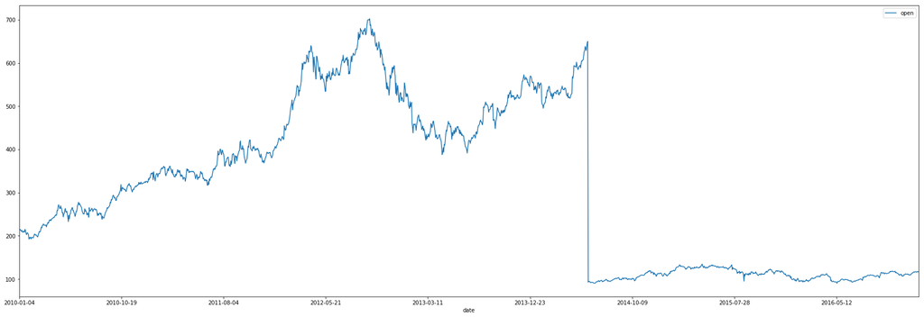

```python
apple = it_prices[it_prices['symbol'] == 'AAPL']
apple.plot(kind='line', x='date', y='open', figsize=(30,10))
```

### The every day stock value changes of Apple Inc. in terms of percentage.

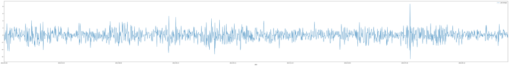

```python
apple.plot(kind='line', x='date', y='percentage', figsize=(80,10))
```

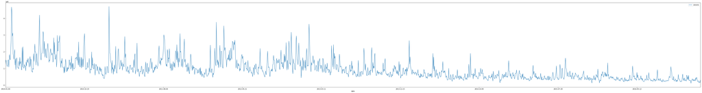

```python
apple.plot(kind='line', x='date', y='volume', figsize=(80,10))
```

### The every day stock value changes of multiple stocks

```
Text(0.5,1,'Stock performance')
```

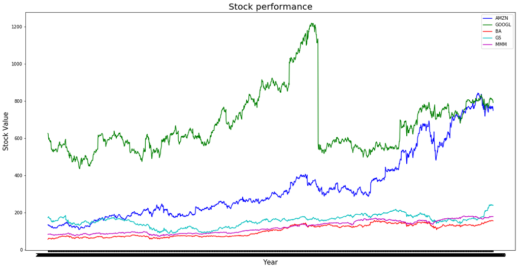

```python
#plotting stock close values vs date
plt.figure(figsize=(20,10))
plt.plot(prices_dataset[prices_dataset['symbol']=='AMZN']['date'],prices_dataset[prices_dataset['symbol']=='AMZN']['close'],'b',label='AMZN')
plt.plot(prices_dataset[prices_dataset['symbol']=='GOOGL']['date'],prices_dataset[prices_dataset['symbol']=='GOOGL']['close'],'g',label='GOOGL')
plt.plot(prices_dataset[prices_dataset['symbol']=='BA']['date'],prices_dataset[prices_dataset['symbol']=='BA']['close'],'r',label='BA')
plt.plot(prices_dataset[prices_dataset['symbol']=='GS']['date'],prices_dataset[prices_dataset['symbol']=='GS']['close'],'c',label='GS')
plt.plot(prices_dataset[prices_dataset['symbol']=='MMM']['date'],prices_dataset[prices_dataset['symbol']=='MMM']['close'],'m',label='MMM')
plt.legend()
plt.xlabel('Year',fontsize=15)
plt.ylabel('Stock Value',fontsize=15)
plt.title('Stock performance',fontsize=20)
```

## 1). Predict the stock value changes in terms of binary classification.

### Randomly produce a binarly guess of the daily changes and test the accuracy

```python
random_guess = prices_dataset
```

```python
random_guess['Trend'] = random_guess['percentage'].apply(lambda x: 1 if x > 0 else 0)
```

```python
# generate a column whose value is series of random int 0 or 1
random_guess['Ran_col'] = pd.Series(np.random.randint(0,2, size=len(random_guess)))
```

```python
random_guess[['Trend', 'Ran_col']].head(5)
```

|  | Trend | Ran_col |
| --- | --- | --- |
| 0 | 1 | 1 |
| 1 | 0 | 1 |
| 2 | 0 | 1 |
| 3 | 1 | 1 |
| 4 | 0 | 0 |

```python
right = random_guess[random_guess['Trend'] == random_guess['Ran_col']]
accuracy_ran = len(right) / len(random_guess)
accuracy_ran
```

```
0.5001268701601383
```

## Interpretation and Analysis:

The random guess has produce an accuracy of about 50%, which is roughly the same as flipping a coin, so this would be a baseline that we should beat if we want to improve our methods to predict the market.

### Pick Cisco as an example, use Naive Bayes and Random Forest classfification to test the accuracy

### Reference: SI618 Lab 10

### -- Step 1: Take a look at the stock price changes of Cisco

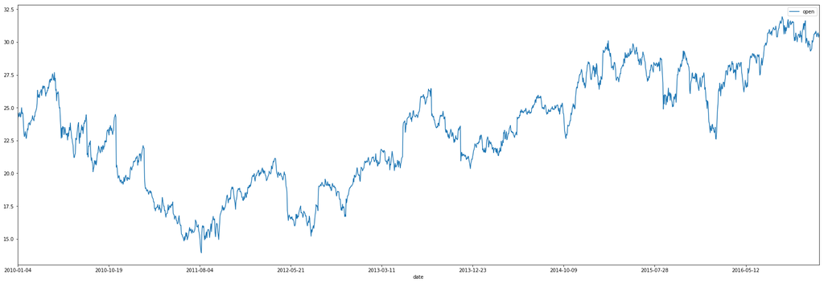

```python
cisco = it_prices[it_prices['symbol'] == 'CSCO']
cisco.plot(kind='line', x='date', y='open', figsize=(30,10))
```

```python
cisco.head(5)
```

|  | date | symbol | open | close | low | high | volume | percentage |
| --- | --- | --- | --- | --- | --- | --- | --- | --- |
| 356 | 2010-01-04 | CSCO | 24.110001 | 24.690001 | 24.010000 | 24.840000 | 59853700.0 | 2.405641 |
| 824 | 2010-01-05 | CSCO | 24.600000 | 24.580000 | 24.379999 | 24.730000 | 45124500.0 | -0.081301 |
| 1292 | 2010-01-06 | CSCO | 24.540001 | 24.420000 | 24.340000 | 24.740000 | 35715700.0 | -0.489002 |
| 1760 | 2010-01-07 | CSCO | 24.299999 | 24.530001 | 24.170000 | 24.570000 | 31531200.0 | 0.946510 |
| 2228 | 2010-01-08 | CSCO | 24.379999 | 24.660000 | 24.250000 | 24.700001 | 39115900.0 | 1.148487 |

### -- Step 2: Add a binary column 'trend' with its value 'up' if the daily return is larger than 0, 'down' if it is smaller than 0

```python
cisco['trend'] = cisco.percentage.apply(lambda x: 'up' if x > 0 else 'down')
cs_df = cisco.drop(['symbol'], axis =1)
cs_df['volume'] = cs_df['volume'] / 100000
cs_df.head(5)
```

|  | date | open | close | low | high | volume | percentage | trend |
| --- | --- | --- | --- | --- | --- | --- | --- | --- |
| 356 | 2010-01-04 | 24.110001 | 24.690001 | 24.010000 | 24.840000 | 598.537 | 2.405641 | up |
| 824 | 2010-01-05 | 24.600000 | 24.580000 | 24.379999 | 24.730000 | 451.245 | -0.081301 | down |
| 1292 | 2010-01-06 | 24.540001 | 24.420000 | 24.340000 | 24.740000 | 357.157 | -0.489002 | down |
| 1760 | 2010-01-07 | 24.299999 | 24.530001 | 24.170000 | 24.570000 | 315.312 | 0.946510 | up |
| 2228 | 2010-01-08 | 24.379999 | 24.660000 | 24.250000 | 24.700001 | 391.159 | 1.148487 | up |

```python
def shift(seq, n):
    n = n % len(seq)
    return seq[n:] + seq[:n]
```

### -- Step 3: Create a new dataframe that each row also keep tracks of the daily close price of the past 10 days

```python
def get_stock_data_analysis(stock_df):
    first_ma = 12
    second_ma = 26
    stock_df = stock_df[::-1]
    data = [round(x,6) for x in stock_df["close"]]

    new_df = pd.DataFrame(stock_df["date"])

    new_df["C_1"] = shift(data,-1)
    new_df["C_2"] = shift(data,-2)
    new_df["C_3"] = shift(data,-3)
    new_df["C_4"] = shift(data,-4)
    new_df["C_5"] = shift(data,-5)
    new_df["C_6"] = shift(data,-6)
    new_df["C_7"] = shift(data,-7)
    new_df["C_8"] = shift(data,-8)
    new_df["C_9"] = shift(data,-9)
    new_df["C_10"] = shift(data,-10)
    new_df["Volume"] = stock_df["volume"]
    new_df['Trend'] = stock_df['trend']
    return new_df
```

```python
cs_nb = get_stock_data_analysis(cs_df)
cs_nb = cs_nb.drop(['date'], axis = 1)
cs_nb.head(5)
```

|  | C_1 | C_2 | C_3 | C_4 | C_5 | C_6 | C_7 | C_8 | C_9 | C_10 | Volume | Trend |
| --- | --- | --- | --- | --- | --- | --- | --- | --- | --- | --- | --- | --- |
| 850874 | 24.690001 | 24.580000 | 24.420000 | 24.530001 | 24.660000 | 24.590000 | 24.200001 | 24.639999 | 24.950001 | 24.400000 | 201.900 | down |
| 850374 | 30.219999 | 24.690001 | 24.580000 | 24.420000 | 24.530001 | 24.660000 | 24.590000 | 24.200001 | 24.639999 | 24.950001 | 109.956 | up |
| 849874 | 30.459999 | 30.219999 | 24.690001 | 24.580000 | 24.420000 | 24.530001 | 24.660000 | 24.590000 | 24.200001 | 24.639999 | 120.222 | down |
| 849374 | 30.420000 | 30.459999 | 30.219999 | 24.690001 | 24.580000 | 24.420000 | 24.530001 | 24.660000 | 24.590000 | 24.200001 | 141.755 | up |
| 848874 | 30.680000 | 30.420000 | 30.459999 | 30.219999 | 24.690001 | 24.580000 | 24.420000 | 24.530001 | 24.660000 | 24.590000 | 91.675 | down |

```python
# get the list of column names for the features
cs_column_list = cs_nb.columns[:-1]
```

```python
spark = SparkSession.builder.appName('664final').getOrCreate()
```

```python
cs_nb = spark.createDataFrame(cs_nb)
```

### -- Step 4: Feed the data into Naive Bayes pipeline and test the accuracy

```python
# randomly split the data to be train data(80%) and test data(20%)
splits = cs_nb.randomSplit([0.8, 0.2], 1234)
cs_train = splits[0]
cs_test = splits[1]

# convert the last column to index
cs_string_indexer = StringIndexer(inputCol="Trend", outputCol="indexed_species")

# merges multiple columns into a vector column
cs_assembler = VectorAssembler(
    inputCols= list(cs_column_list),
    outputCol="features"
)

# create the trainer and set its parameters; set smoothing=10.0, which represents add-one smoothing
cs_nb_model = NaiveBayes(featuresCol='features', labelCol='indexed_species', smoothing=1.0, modelType="multinomial")

# maps the column of prediction indices back to the original species labels
cs_labelConverter = IndexToString(inputCol="prediction", outputCol="predictedLabel",
                               labels=cs_string_indexer.fit(cs_nb).labels)

# Chain indexers and forest in a Pipeline
cs_pipeline = Pipeline(stages=[cs_string_indexer, cs_assembler, cs_nb_model, cs_labelConverter])

# Train the pipeline on the train dataset
cs_model = cs_pipeline.fit(cs_train)

# select example rows to display.
cs_predictions = cs_model.transform(cs_test)

# compute accuracy on the test set
evaluator = MulticlassClassificationEvaluator(labelCol="indexed_species", predictionCol="prediction",
                                              metricName="accuracy")
accuracy = evaluator.evaluate(cs_predictions)
print("Test set accuracy = " + str(accuracy))
```

```
Test set accuracy = 0.5058823529411764
```

### Feed the data into Random Forest pipeline and test the accuracy

```python
cs_rf_df = cs_nb
```

```
Test set accuracy = 0.55
```

```
None
```

[figure not shown]

```python
# create the trainer and set its parameters; set smoothing=10.0, which represents add-one smoothing
cs_rf = RandomForestClassifier(labelCol="indexed_species", featuresCol="features", numTrees=10)

# Chain indexers and forest in a Pipeline
cs_rf_pipeline = Pipeline(stages=[cs_string_indexer, cs_assembler, cs_rf, cs_labelConverter])

# Train the pipeline on the train dataset
cs_rf_model = cs_rf_pipeline.fit(cs_train)

# select example rows to display.
cs_rf_predictions = cs_rf_model.transform(cs_test)

# compute accuracy on the test set
evaluator = MulticlassClassificationEvaluator(labelCol="indexed_species", predictionCol="prediction",
                                              metricName="accuracy")
accuracy = evaluator.evaluate(cs_rf_predictions)
print("Test set accuracy = " + str(accuracy))

# compute feature importance of each predictor
featureImportances = pd.DataFrame({"index":cs_rf_df.columns[:-1],"featureImportances":cs_rf_model.stages[2].featureImportances})\
  .sort_values("featureImportances", ascending=False)

# visualize the feature importance using seaborn
f, ax = plt.subplots(figsize=(12, 7))
sns.set(style="darkgrid")
sns.barplot(y="index",x="featureImportances",data=featureImportances)

display(f.figure)
```

## 2). Predict the stock value changes in terms of numeric changes.

### MLP and Kfold cross validation using Tensorflow

### Reference: https://gist.github.com/fedden/b1e98a3b5b5f34624f797e20244e4902

### -- Step 1: Keeps only the open price and close price of the day and perform a Kfold analysis

```python
cs2 = cs
cs2.head(5)
```

| date | open | low | high | close |
| --- | --- | --- | --- | --- |
| 2010-01-04 | 0.565556 | 0.580488 | 0.601234 | 0.604190 |
| 2010-01-05 | 0.592778 | 0.600542 | 0.595064 | 0.598126 |
| 2010-01-06 | 0.589444 | 0.598374 | 0.595625 | 0.589305 |
| 2010-01-07 | 0.576111 | 0.589160 | 0.586091 | 0.595369 |
| 2010-01-08 | 0.580555 | 0.593496 | 0.593382 | 0.602536 |

```python
cs_mlp = cisco[['open', 'close']]
cs_mlp.head(5)
```

|  | open | close |
| --- | --- | --- |
| 356 | 24.110001 | 24.690001 |
| 824 | 24.600000 | 24.580000 |
| 1292 | 24.540001 | 24.420000 |
| 1760 | 24.299999 | 24.530001 |
| 2228 | 24.379999 | 24.660000 |

### -- Step 2: Create a matrix of the open and close prices for multilayer perceptron

```python
cs_mlp.as_matrix()
```

```
array([[ 24.110001,  24.690001],
       [ 24.6     ,  24.58    ],
       [ 24.540001,  24.42    ],
       ...,
       [ 30.700001,  30.42    ],
       [ 30.370001,  30.459999],
       [ 30.559999,  30.219999]])
```

### -- Step 3: Initialize the model

```python
# reset the tensorflow graph
tf.reset_default_graph()

# Initiate with parameters
amount_epochs = 50
learning_rate = 0.001
batch_size = 64
net_hidden_sizes = [64, 32, 4]
l2_strength = 0.01
non_linearity = tf.nn.relu
dropout_amount = 0.4

# The input to the graph - the targets (close) and the inputs(open). Also a placeholder to pass a variable dropout rate.
net_input = tf.placeholder(tf.float32, shape=[None, 1])
net_target = tf.placeholder(tf.float32, shape=[None, 1])
dropout_prob = tf.placeholder(tf.float32)

# L2 regularisation to penalise the weights from growing too
# large. Useful to prevent overfitting.
regulariser = tf.contrib.layers.l2_regularizer(scale=l2_strength)
```

### -- Step 4: Build the multilayer perceptron network

```python
# Build the network from the list of dimensions. Apply l2 and
# dropout regularisation to the layers.
net = net_input
for size in net_hidden_sizes:
    net = tf.layers.dense(inputs=net,
                          units=size,
                          activation=non_linearity,
                          kernel_regularizer=regulariser)
    net = tf.layers.dropout(inputs=net,
                            rate=dropout_prob)

# The models prediction has a linear output.
net_output = tf.layers.dense(inputs=net,
                             units=1,
                             activation=None,
                             kernel_regularizer=regulariser)

# The main loss for penalising the network on how well it does.
loss = tf.losses.mean_squared_error(labels=net_target,
                                    predictions=net_output)

# TensorFlows manner of applying l2 to the loss.
l2_variables = tf.get_collection(tf.GraphKeys.REGULARIZATION_LOSSES)
l2_loss = tf.contrib.layers.apply_regularization(regulariser,
                                                 l2_variables)
total_loss = loss + l2_loss
```

### -- Step 5: Train the model

```python
# Train and initialisation TensorFlow operations to be ran
# in the session.
train_op = tf.train.AdamOptimizer(learning_rate).minimize(total_loss)
init_op = tf.global_variables_initializer()
```

### -- Step 6: Divide the data into 5 stacks, use each of them as test data and the rest as training data, and test to see the error. Redo the cross validation for 20 times and plot the error to see whether it is stable or not

```python
kfold_error = []
for kk in range(20):
    with tf.Session() as sess:

        amount_folds = 5
        k_folds = KFold(n_splits=amount_folds)
        data = cs_mlp.as_matrix()
        fold_errors = []
        fold_iteration = 0

        # Cross validate the dataset, using K-Fold.
        for train_indices, test_indices in k_folds.split(data):

            # Each new fold, reinitialise the network.
            sess.run(init_op)

            # Training phase.
            for epoch in range(amount_epochs):

                # Each new epoch, reshuffle the train set.
                random_train_indices = np.random.permutation(train_indices)
                train_set = data[random_train_indices]

                # Loop over the train set and optimise the network.
                for begin in range(0, len(train_set), batch_size):
                    end = begin + batch_size
                    batch_x = train_set[begin:end].T[0].reshape((-1, 1))
                    batch_y = train_set[begin:end].T[1].reshape((-1, 1))

                    sess.run(train_op, feed_dict={
                        net_input: batch_x,
                        net_target: batch_y,
                        dropout_prob: dropout_amount
                    })

            # Testing phase.
            test_set = data[test_indices]

            # Collate the error over the test set.
            all_error = []
            for begin in range(0, len(test_set), batch_size):
                end = begin + batch_size
                batch_x = train_set[begin:end].T[0].reshape((-1, 1))
                batch_y = train_set[begin:end].T[1].reshape((-1, 1))

                error = sess.run(loss, feed_dict={
                    net_input: batch_x,
                    net_target: batch_y,
                    dropout_prob: 1.0
                })
                all_error.append(error)

            all_error = np.array(all_error).reshape((-1))

            kfold_error.append(np.mean(all_error))
```

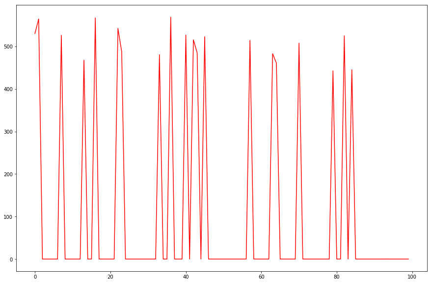

```python
plt.figure(figsize=(15,10))
plt.plot(kfold_error, color='r')
plt.show()
```

## Interpretation and Analysis:

The fluctuation of the error indicates that using only the prices as features would not produce reasonable prediction.

### Use Monte Carlo Simulation to predict the stock prices. Intuitive enough that this wouldn't work but it is interesting to give a try.

### Reference: https://github.com/siddharthravindran/Stock-Market-Analysis-Project/blob/master/Stock%20Market%20Analysis.ipynb

### Use the stock prices of BAC to perform the analysis.

```python
bac = prices_dataset[prices_dataset['symbol']=='BAC']
```

### I use the price at the beginning of year 2015, the mean and standard deviation of year 2015 for the simulation

```python
bac_2015 = bac[bac['year'] == '2015']
```

```python
bac_2015['percentage'] = bac_2015['percentage'] / 100
bac_2015.head(5)
```

|  | date | symbol | open | close | low | high | volume | percentage | year |
| --- | --- | --- | --- | --- | --- | --- | --- | --- | --- |
| 600486 | 2015-01-02 | BAC | 17.990000 | 17.900000 | 17.680000 | 18.030001 | 48951100.0 | -0.005003 | 2015 |
| 600980 | 2015-01-05 | BAC | 17.790001 | 17.379999 | 17.290001 | 17.809999 | 105605500.0 | -0.023047 | 2015 |
| 601474 | 2015-01-06 | BAC | 17.420000 | 16.860001 | 16.780001 | 17.440001 | 144912400.0 | -0.032147 | 2015 |
| 601968 | 2015-01-07 | BAC | 17.139999 | 16.940001 | 16.870001 | 17.180000 | 104603800.0 | -0.011668 | 2015 |
| 602462 | 2015-01-08 | BAC | 17.160000 | 17.290001 | 17.100000 | 17.340000 | 73388500.0 | 0.007576 | 2015 |

```python
bac_2015_start = bac_2015['open'].head(1)
bac_2015_start
```

```
600486    17.99
Name: open, dtype: float64
```

### Take the price of 2016 as reference

```python
bac_2016_end = bac[bac['year'] == '2016']['open']
```

```python
bac_2016_end.head(1)
```

```
725443    16.450001
Name: open, dtype: float64
```

```python
days = 365

dt = 1/days

mu = bac_2015['percentage'].mean()

sigma = bac_2015['percentage'].std()
```

```python
def stock_monte_carlo(start_price, days, mu, sigma):
    price = np.zeros(days)
    price[0] = start_price

    shock = np.zeros(days)
    drift = np.zeros(days)

    for x in range(1, days):

        shock[x] = np.random.normal(loc = mu*dt, scale = sigma * np.sqrt(dt))
        drift[x] = mu * dt
        price[x] = price[x-1] + (price[x-1] * (drift[x] + shock[x]))

    return price
```

```
Text(0.5,1,'Monte Carlo Analysis for BAC')
```

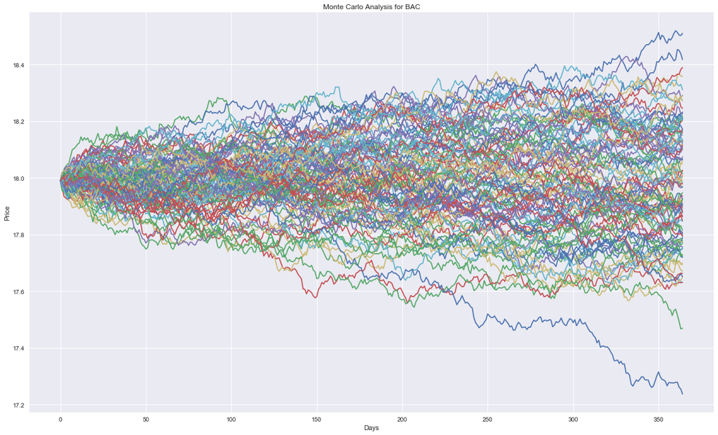

```python
start_price = 17.99
plt.figure(figsize = (20, 12))
for run in range(100):
    plt.plot(stock_monte_carlo(start_price, days, mu, sigma))


plt.xlabel('Days')
plt.ylabel('Price')
plt.title('Monte Carlo Analysis for BAC')
```

```python
runs = 10000

simulations = np.zeros(runs)

for run in range(runs):
    simulations[run] = stock_monte_carlo(start_price, days, mu, sigma)[days-1]
```

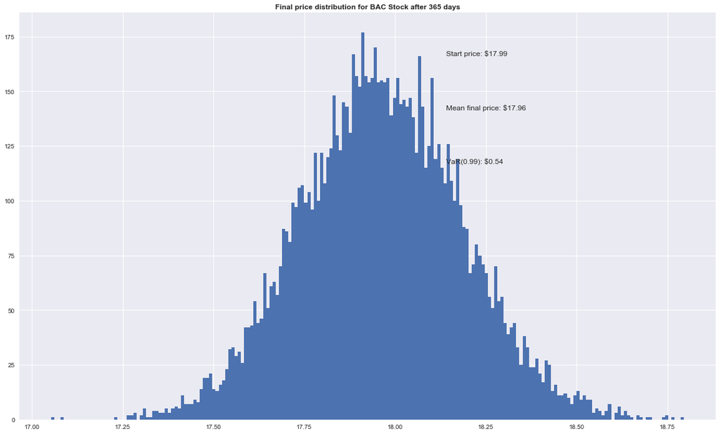

```python
q = np.percentile(simulations, 1)

plt.figure(figsize = (20, 12))

plt.hist(simulations, bins = 200)

# Starting Price
plt.figtext(0.6, 0.8, s="Start price: $%.2f" %start_price)
# Mean ending price
plt.figtext(0.6, 0.7, "Mean final price: $%.2f" % simulations.mean())

# Variance of the price (within 99% confidence interval)
plt.figtext(0.6, 0.6, "VaR(0.99): $%.2f" % (start_price - q,))

# Title
plt.title(u"Final price distribution for BAC Stock after %s days" % days, weight='bold');
```

## 3). Find the relationship of stock prices changes w.r.t daily trading volume.

### Reference: https://github.com/devsawant92/visualization-stock-Data-/blob/master/Sawant_Devendra_Assignment2.ipynb

### Reference: https://github.com/NavaneethKrishnaV/Stock-Visualizations/blob/master/Vadapalli_Navaneeth%20Krishna_Stock%20viz..ipynb

```python
prices_dataset['year']=prices_dataset['date'].apply(lambda x: x[:4])
prices_dataset.head(5)
```

|  | date | symbol | open | close | low | high | volume | percentage | year |
| --- | --- | --- | --- | --- | --- | --- | --- | --- | --- |
| 0 | 2016-01-05 00:00:00 | WLTW | 123.430000 | 125.839996 | 122.309998 | 126.250000 | 2163600.0 | 1.952520 | 2016 |
| 1 | 2016-01-06 00:00:00 | WLTW | 125.239998 | 119.980003 | 119.940002 | 125.540001 | 2386400.0 | -4.199932 | 2016 |
| 2 | 2016-01-07 00:00:00 | WLTW | 116.379997 | 114.949997 | 114.930000 | 119.739998 | 2489500.0 | -1.228733 | 2016 |
| 3 | 2016-01-08 00:00:00 | WLTW | 115.480003 | 116.620003 | 113.500000 | 117.440002 | 2006300.0 | 0.987184 | 2016 |
| 4 | 2016-01-11 00:00:00 | WLTW | 117.010002 | 114.970001 | 114.089996 | 117.330002 | 1408600.0 | -1.743442 | 2016 |

### Look at the sum of volume of year 2016

```python
year_2016 = prices_dataset[prices_dataset['year'] == '2016']
```

```python
volume = year_2016[['symbol','volume']]
```

```python
volume=volume.groupby('symbol').sum()
```

```python
volume =volume.sort_values(by = 'volume', ascending = False)
```

```python
volume=volume.reset_index()
```

```python
volume.head(5)
```

|  | symbol | volume |
| --- | --- | --- |
| 0 | BAC | 2.728408e+10 |
| 1 | CHK | 1.164961e+10 |
| 2 | FCX | 1.046871e+10 |
| 3 | AAPL | 9.680671e+09 |
| 4 | F | 8.995790e+09 |

```python
import squarify
```

### Find the companies with the largest sum volume of year 2016

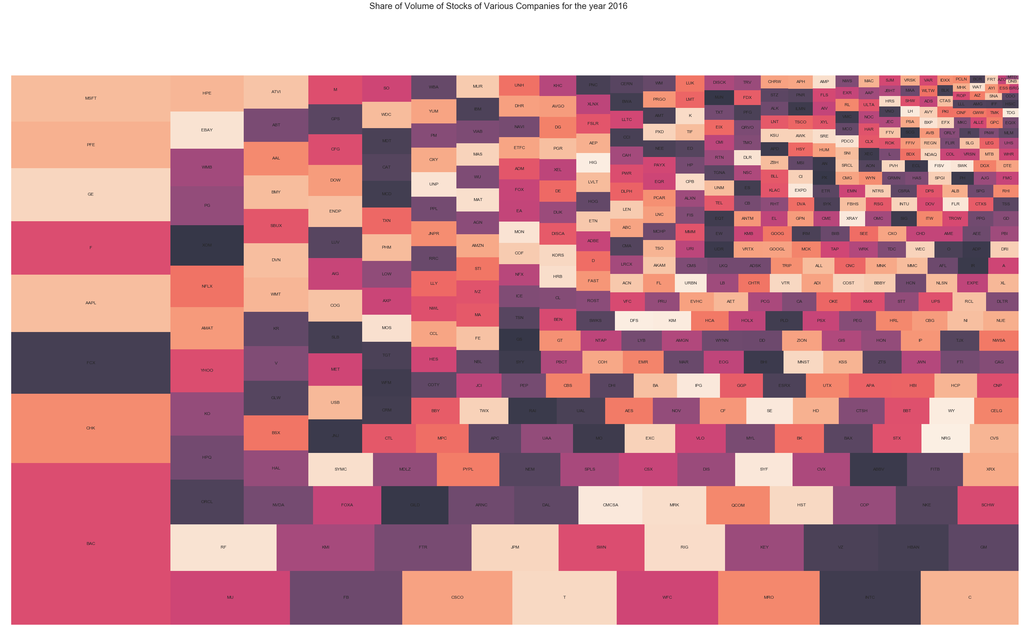

```python
squarify.plot(sizes=volume['volume'],label=volume['symbol'], alpha=.8 )
fig = plt.gcf()
fig.set_size_inches(50, 28)
plt.suptitle('Share of Volume of Stocks of Various Companies for the year 2016', fontsize=24)
plt.axis('off')
plt.show()
```

```python
bac = prices_dataset[prices_dataset['symbol']=='BAC']
chk = prices_dataset[prices_dataset['symbol']=='CHK']
fcx = prices_dataset[prices_dataset['symbol']=='FCX']
aapl = prices_dataset[prices_dataset['symbol']=='AAPL']
f = prices_dataset[prices_dataset['symbol']=='F']
```

### Plot them and analyze the plots

```
Text(0.5,1,'Volume,Close vs Date(F)')
```

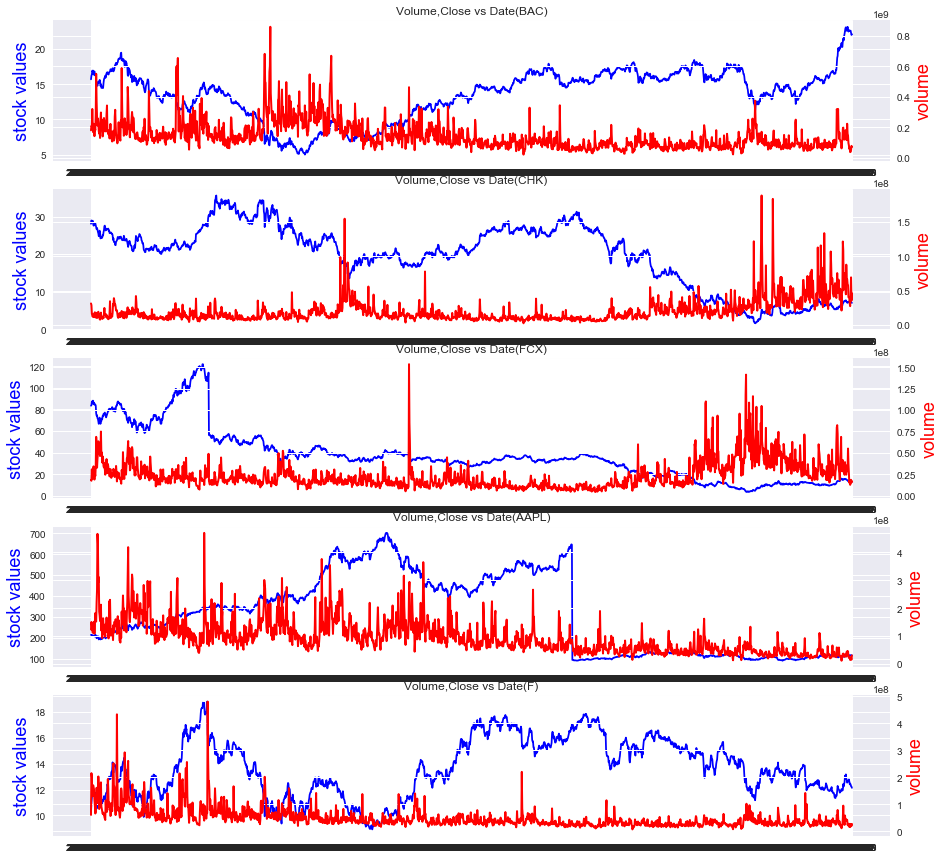

```python
#plotting stocke close values and volume vs date for tope 5 companies.
fig, axes = plt.subplots(nrows=5, ncols=1, figsize=(15,15))
axes[0].plot('date','close',data=bac,color='blue')
axes[0].set_ylabel(r"stock values", fontsize=18, color="blue")
ax0 = axes[0].twinx()
ax0.plot('date','volume',data=bac, lw=2, color="red")
ax0.set_ylabel(r"volume", fontsize=18, color="red")
axes[0].set_title('Volume,Close vs Date(BAC)')

axes[1].plot('date','close',data=chk,color='blue')
axes[1].set_ylabel(r"stock values", fontsize=18, color="blue")
ax1 = axes[1].twinx()
ax1.plot('date','volume',data=chk, lw=2, color="red")
ax1.set_ylabel(r"volume", fontsize=18, color="red")
axes[1].set_title('Volume,Close vs Date(CHK)')

axes[2].plot('date','close',data=fcx,color='blue')
axes[2].set_ylabel(r"stock values", fontsize=18, color="blue")
ax2 = axes[2].twinx()
ax2.plot('date','volume',data=fcx, lw=2, color="red")
ax2.set_ylabel(r"volume", fontsize=18, color="red")
axes[2].set_title('Volume,Close vs Date(FCX)')

axes[3].plot('date','close',data=aapl,color='blue')
axes[3].set_ylabel(r"stock values", fontsize=18, color="blue")
ax3 = axes[3].twinx()
ax3.plot('date','volume',data=aapl, lw=2, color="red")
ax3.set_ylabel(r"volume", fontsize=18, color="red")
axes[3].set_title('Volume,Close vs Date(AAPL)')

axes[4].plot('date','close',data=f,color='blue')
axes[4].set_ylabel(r"stock values", fontsize=18, color="blue")
ax4 = axes[4].twinx()
ax4.plot('date','volume',data=f, lw=2, color="red")
ax4.set_ylabel(r"volume", fontsize=18, color="red")
axes[4].set_title('Volume,Close vs Date(F)')
```

```python
heat_map = prices_dataset.groupby('symbol').pct_change()
```

### Find out if the volume and price changes are highly related

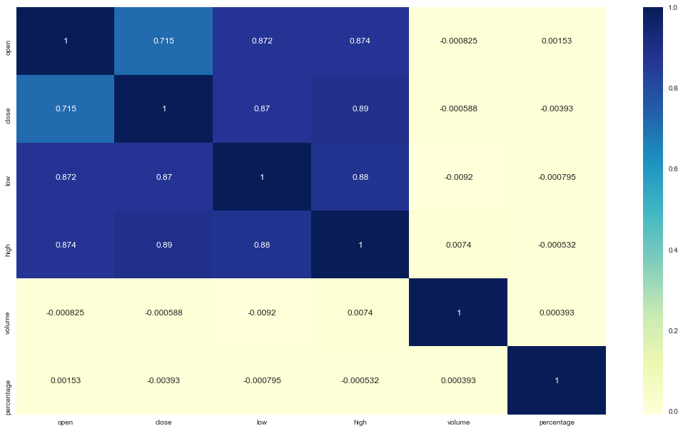

```python
fig = plt.gcf()
fig.set_size_inches(18.5, 10.5)
sns.heatmap(heat_map.corr(),annot=True,fmt=".3g",cmap='YlGnBu')
```

## 4).Explore the difference in stock value changes for stocks that belong to different sectors

### Reference: https://github.com/devsawant92/visualization-stock-Data-/blob/master/Sawant_Devendra_Assignment2.ipynb

### Sectors in S&P 500

```python
sector = securities_dataset['GICS Sector']
sector.unique()
```

```
array(['Industrials', 'Health Care', 'Information Technology',
       'Consumer Discretionary', 'Utilities', 'Financials', 'Materials',
       'Consumer Staples', 'Real Estate', 'Energy',
       'Telecommunications Services'], dtype=object)
```

### Take a deeper look into sector of 'Information Technology'

```python
sector_it = securities_dataset[securities_dataset['GICS Sector'] == 'Information Technology']
```

```python
it_list = sector_it['Ticker symbol'].unique()
it_list
```

```
array(['ACN', 'ATVI', 'ADBE', 'AKAM', 'ADS', 'GOOGL', 'GOOG', 'APH', 'ADI',
       'AAPL', 'AMAT', 'ADSK', 'ADP', 'AVGO', 'CA', 'CSCO', 'CTXS', 'CTSH',
       'GLW', 'CSRA', 'EBAY', 'EA', 'FFIV', 'FB', 'FIS', 'FSLR', 'FISV',
       'FLIR', 'GPN', 'HRS', 'HPE', 'HPQ', 'INTC', 'IBM', 'INTU', 'JNPR',
       'KLAC', 'LRCX', 'LLTC', 'MA', 'MCHP', 'MU', 'MSFT', 'MSI', 'NTAP',
       'NFLX', 'NVDA', 'ORCL', 'PAYX', 'PYPL', 'QRVO', 'QCOM', 'RHT',
       'CRM', 'STX', 'SWKS', 'SYMC', 'TEL', 'TDC', 'TXN', 'TSS', 'VRSN',
       'V', 'WDC', 'WU', 'XRX', 'XLNX', 'YHOO'], dtype=object)
```

### Keep only the companies in the IT sector in prices dataset

```python
it_prices = prices_dataset[prices_dataset['symbol'].isin(it_list)]
it_prices.head(5)
```

|  | date | symbol | open | close | low | high | volume | percentage |
| --- | --- | --- | --- | --- | --- | --- | --- | --- |
| 254 | 2010-01-04 | AAPL | 213.429998 | 214.009998 | 212.380001 | 214.499996 | 123432400.0 | 0.271752 |
| 257 | 2010-01-04 | ACN | 41.520000 | 42.070000 | 41.500000 | 42.200001 | 3650100.0 | 1.324663 |
| 258 | 2010-01-04 | ADBE | 36.650002 | 37.090000 | 36.650002 | 37.299999 | 4710200.0 | 1.200540 |
| 259 | 2010-01-04 | ADI | 31.790001 | 31.670000 | 31.610001 | 32.189999 | 2102700.0 | -0.377480 |
| 261 | 2010-01-04 | ADP | 43.540000 | 42.830002 | 42.700002 | 43.540000 | 3930100.0 | -1.630680 |

```python
from functools import reduce
```

```python
def combined_sector_df(sector_list):
    df_list = []
    for it_inc in sector_list:
        df_name = 'df_' + it_inc
        df_name = prices_dataset[prices_dataset['symbol'] == it_inc]
        df_name = df_name.drop(['symbol', 'open', 'close', 'low', 'high', 'volume'], axis=1)
        df_name = df_name.rename(columns={'percentage': it_inc})
        if len(df_name) == 1762:
            df_list.append(df_name)
        else:
            sector_list.remove(it_inc)

    df_final = reduce(lambda left,right: pd.merge(left,right,on='date'), df_list)
    return sector_list, df_final
```

```python
def df_plot_return_all(sector_list, df_final):
    plt.figure(figsize=(20,10))
    for it_inc in sector_list:
        df_final[it_inc].plot.kde(label=it_inc,alpha=0.5,linewidth =4)
```

```python
def df_plot_return_avg(sector_name, sector_list, df_final):
    summary_ave_data = df_final.copy()
    summary_ave_data['average'] = summary_ave_data.mean(numeric_only=True, axis=1)
    plt.figure(figsize=(12,7))
#     summary_ave_data['average'].plot.kde(label='avg',alpha=0.5,linewidth =4)
    summary_ave_data = summary_ave_data.rename(columns={'average': sector_name})
    summary_ave_data = summary_ave_data[['date', sector_name]]
    return summary_ave_data
```

### Plot the distribution of daily return of each company that belong to IT sector

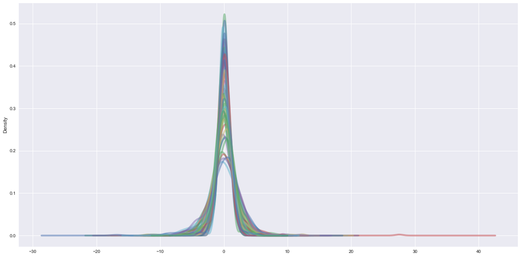

[figure not shown]

```python
it_list, it_final = combined_sector_df(it_list)
df_plot_return_all(it_list, it_final)
df_plot_return_avg(it_list, it_final)
```

### Some stock did not have value record from year 2010, so we have to exclude these stock

```python
nn = []
for l in range(len(df_list1)-1):
    nn.append(len(df_list1[l]))
nn_value = list(set(nn))
```

```python
nn_value
```

```
[1008, 1762, 786, 126]
```

```python
sectors = list(sector.unique())
avg_df_list = []
for each_sector in sectors:
    sector_each = 'sector' + each_sector
    sector_each = securities_dataset[securities_dataset['GICS Sector'] == each_sector]
    s_list = list(sector_each['Ticker symbol'].unique())

    ss_list, ss_final = combined_sector_df(s_list)
    if len(ss_final) != 0:
        avg_df_list.append(df_plot_return_avg(each_sector, ss_list, ss_final))
avg_final = reduce(lambda left,right: pd.merge(left,right,on='date'), avg_df_list)
```

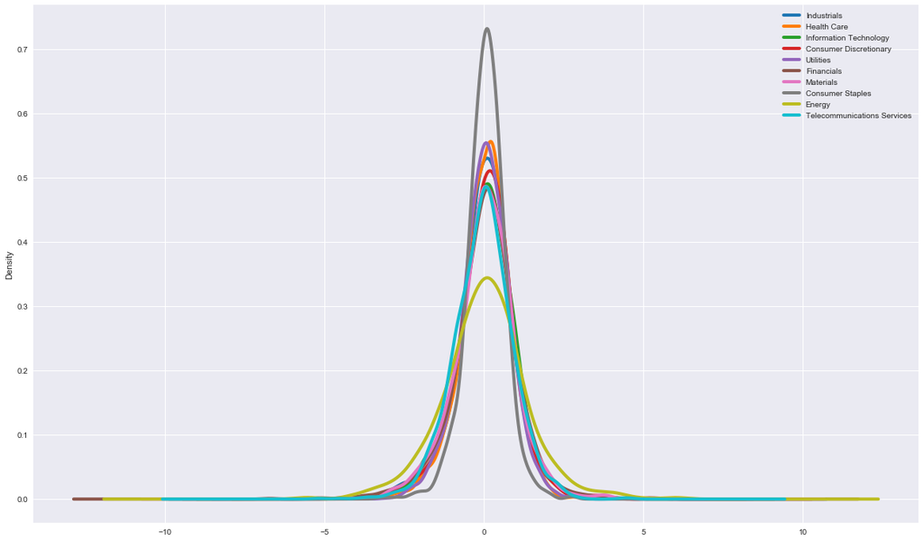

```python
avg_final.plot.kde(label='avg',alpha=1,linewidth =4, color=["#1f77b4", "#ff7f0e", "#2ca02c", "#d62728", "#9467bd", "#8c564b", "#e377c2", "#7f7f7f", "#bcbd22", "#17becf"],figsize = (20,12))
```

```python
avg_final.head(5)
```

|  | date | MMM | AYI | ALK | AME | ARNC | BA | CHRW | CAT | CTAS | ... | RIG | VLO | WMB | Energy | T | CTL | FTR | LVLT | VZ | Telecommunications Services |
| --- | --- | --- | --- | --- | --- | --- | --- | --- | --- | --- | --- | --- | --- | --- | --- | --- | --- | --- | --- | --- | --- |
| 0 | 2010-01-04 | -0.084245 | 0.418055 | 0.143593 | 0.390122 | 1.092889 | 0.825555 | 0.202633 | 1.561140 | 0.609985 | ... | 2.722533 | 3.710158 | 0.792889 | 1.833760 | 0.598381 | 0.328404 | 0.887199 | 5.228758 | -0.359280 | 1.336693 |
| 1 | 2010-01-05 | -0.362322 | 1.310655 | 5.811281 | -0.569213 | -4.159236 | 3.146667 | -1.808042 | 1.195561 | 0.152037 | ... | 1.641227 | 1.269327 | 1.720167 | 1.090466 | -0.905923 | -0.108806 | -0.628141 | 1.226994 | -0.089901 | -0.101155 |
| 2 | 2010-01-06 | -0.250356 | -0.378491 | 0.551727 | -0.077917 | 4.046594 | 2.661856 | -0.830163 | 0.422440 | 0.878194 | ... | 3.875800 | 2.283845 | 2.822064 | 1.136431 | -1.216458 | -3.448281 | -2.377972 | -0.621118 | -2.205888 | -1.973944 |
| 3 | 2010-01-07 | 0.492082 | 3.008948 | -0.793436 | 0.968584 | 0.544800 | 4.520254 | -0.508061 | 0.623944 | 2.500000 | ... | 0.220244 | 0.905256 | -0.576198 | 0.019977 | -1.015232 | -1.355164 | -0.640205 | 0.625000 | -1.152649 | -0.707650 |
| 4 | 2010-01-08 | 0.752776 | 1.033110 | -1.904496 | 1.970957 | 3.402197 | 0.097493 | 1.499115 | 1.839662 | 1.317775 | ... | 2.751075 | -1.267782 | 0.892456 | 1.231558 | -0.696229 | -0.428700 | -1.538462 | -3.703704 | 0.284268 | -1.216565 |

5 rows × 420 columns

## 5). Predict the stock value changes using LSTM

### Reference: https://www.kaggle.com/benjibb/lstm-stock-prediction-20170507

### The stock price is consistent over the time and can be used to train a LSTM model

### -- Step 1: Normalize the data

```python
pd.options.mode.chained_assignment = None
```

```python
def normalize_data(df):
    min_max_scaler = preprocessing.MinMaxScaler()
    df['open'] = min_max_scaler.fit_transform(df.open.values.reshape(-1,1))
    df['close'] = min_max_scaler.fit_transform(df.close.values.reshape(-1,1))
    df['high'] = min_max_scaler.fit_transform(df.high.values.reshape(-1,1))
    df['low'] = min_max_scaler.fit_transform(df.low.values.reshape(-1,1))
    return df
```

### -- Step 2: Divide the data into training data and testing data

```python
def load_data(stock, seq_len):
    amount_of_features = len(stock.columns) # 4
#     print(amount_of_features)
    data = stock.as_matrix()
    sequence_length = seq_len + 1
    result = []

    for index in range(len(data) - sequence_length):
        result.append(data[index: index + sequence_length]) # sliding window with a size of sequence_length

    result = np.array(result)
    row = round(0.8 * result.shape[0]) # 80% split
    train = result[:int(row), :]
#     print(result)

    x_train = train[:, :-1]
#     print(x_train.shape)
    y_train = train[:, -1][:,-1]
#     print(y_train.shape)

    x_test = result[int(row):, :-1]
    y_test = result[int(row):, -1][:,-1]

    x_train = np.reshape(x_train, (x_train.shape[0], x_train.shape[1], amount_of_features))
    x_test = np.reshape(x_test, (x_test.shape[0], x_test.shape[1], amount_of_features))

    return x_train, y_train, x_test, y_test
```

### -- Step 3: Build the LSTM model with given parameters

```python
def build_model(layers):
    d = 0.3
    model = Sequential()

    model.add(LSTM(256, input_shape=(layers[1], layers[0]), return_sequences=True))
    model.add(Dropout(d))

    model.add(LSTM(256, input_shape=(layers[1], layers[0]), return_sequences=False))
    model.add(Dropout(d))

    model.add(Dense(32,kernel_initializer="uniform",activation='relu'))
    model.add(Dense(1,kernel_initializer="uniform",activation='linear'))

    # adam = keras.optimizers.Adam(decay=0.2)

    start = time.time()
    model.compile(loss='mse',optimizer='adam', metrics=['accuracy'])
    print("Compilation Time : ", time.time() - start)
    return model
```

### -- Step 4: Denomalize the predicted price changes

```python
def denormalize(df, normalized_value):
    df = df['close'].values.reshape(-1,1)
    normalized_value = normalized_value.reshape(-1,1)

    #return df.shape, p.shape
    min_max_scaler = preprocessing.MinMaxScaler()
    a = min_max_scaler.fit_transform(df)
    new = min_max_scaler.inverse_transform(normalized_value)
    return new
```

### -- Example with Cisco

```python
cs = normalize_data(cisco)
```

```python
cs = cs.drop(['symbol', 'volume', 'percentage'], axis = 1)
cs.head(5)
```

|  | date | open | close | low | high |
| --- | --- | --- | --- | --- | --- |
| 356 | 2010-01-04 | 0.565556 | 0.604190 | 0.580488 | 0.601234 |
| 824 | 2010-01-05 | 0.592778 | 0.598126 | 0.600542 | 0.595064 |
| 1292 | 2010-01-06 | 0.589444 | 0.589305 | 0.598374 | 0.595625 |
| 1760 | 2010-01-07 | 0.576111 | 0.595369 | 0.589160 | 0.586091 |
| 2228 | 2010-01-08 | 0.580555 | 0.602536 | 0.593496 | 0.593382 |

```python
cols = list(cs.columns.values)
cols.pop(cols.index('close'))
cs = cs[cols + ['close']]
cs.head(5)
```

|  | date | open | low | high | close |
| --- | --- | --- | --- | --- | --- |
| 356 | 2010-01-04 | 0.565556 | 0.580488 | 0.601234 | 0.604190 |
| 824 | 2010-01-05 | 0.592778 | 0.600542 | 0.595064 | 0.598126 |
| 1292 | 2010-01-06 | 0.589444 | 0.598374 | 0.595625 | 0.589305 |
| 1760 | 2010-01-07 | 0.576111 | 0.589160 | 0.586091 | 0.595369 |
| 2228 | 2010-01-08 | 0.580555 | 0.593496 | 0.593382 | 0.602536 |

```python
cs.set_index('date', inplace=True)
cs.head(5)
```

| date | open | low | high | close |
| --- | --- | --- | --- | --- |
| 2010-01-04 | 0.565556 | 0.580488 | 0.601234 | 0.604190 |
| 2010-01-05 | 0.592778 | 0.600542 | 0.595064 | 0.598126 |
| 2010-01-06 | 0.589444 | 0.598374 | 0.595625 | 0.589305 |
| 2010-01-07 | 0.576111 | 0.589160 | 0.586091 | 0.595369 |
| 2010-01-08 | 0.580555 | 0.593496 | 0.593382 | 0.602536 |

```python
window_size = 25
```

```python
cs_xtrain, cs_ytrain, cs_xtest, cs_ytest = load_data(cs, window_size)
```

```python
model = build_model([4,window_size,1])
```

```
Compilation Time :  0.034090280532836914
```

```python
model.fit(cs_xtrain,cs_ytrain,batch_size=512,epochs=90,validation_split=0.1,verbose=1)
```

```
Train on 1250 samples, validate on 139 samples
```

```
<keras.callbacks.History at 0x1d72ca74828>
```

```python
cs_ypred = model.predict(cs_xtest)
```

```python
cisco_actual = it_prices[it_prices['symbol'] == 'CSCO']
cols = list(cisco_actual.columns.values)
cols.pop(cols.index('close'))
cisco_actual = cisco_actual[cols + ['close']]
cisco_actual = cisco_actual.drop(['symbol', 'volume', 'percentage'], axis = 1)
cisco_actual.set_index('date', inplace=True)
cisco_actual.head(5)
```

| date | open | low | high | close |
| --- | --- | --- | --- | --- |
| 2010-01-04 | 24.110001 | 24.010000 | 24.840000 | 24.690001 |
| 2010-01-05 | 24.600000 | 24.379999 | 24.730000 | 24.580000 |
| 2010-01-06 | 24.540001 | 24.340000 | 24.740000 | 24.420000 |
| 2010-01-07 | 24.299999 | 24.170000 | 24.570000 | 24.530001 |
| 2010-01-08 | 24.379999 | 24.250000 | 24.700001 | 24.660000 |

```python
pred = denormalize(cisco_actual, cs_ypred)
test = denormalize(cisco_actual, cs_ytest)
```

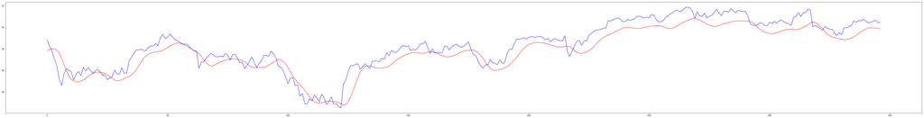

```python
import matplotlib.pyplot as plt2
plt2.figure(figsize=(80,10))
plt2.plot(pred,color='red', label='Prediction')
plt2.plot(test,color='blue', label='Actual')
plt2.show()
```

## Interpretation and Analysis:

The prediction is quite consistent with the actual stock prices changes. Though the predicted price is a smooth curve that deviate from reality, the model can capture the fluctuation of the stock price. However, I feel this model and method is problematic because the Efficient Market Hypothesis in finance proposes that stock prices should only react to new information but not the past information.